# Assignment 5

Manuela Giansante

2023-03-28

```r
# Packages needed
library(fpp3)
library(fpp2)
library(dplyr)
library(ggplot2)
library(cowplot)
library(forecast)
library(tidyverse)
library(feasts)
library(reshape2)
library(lubridate)
library(kableExtra)
```

### a. Plot the selected time series and comment the general features you can observe.

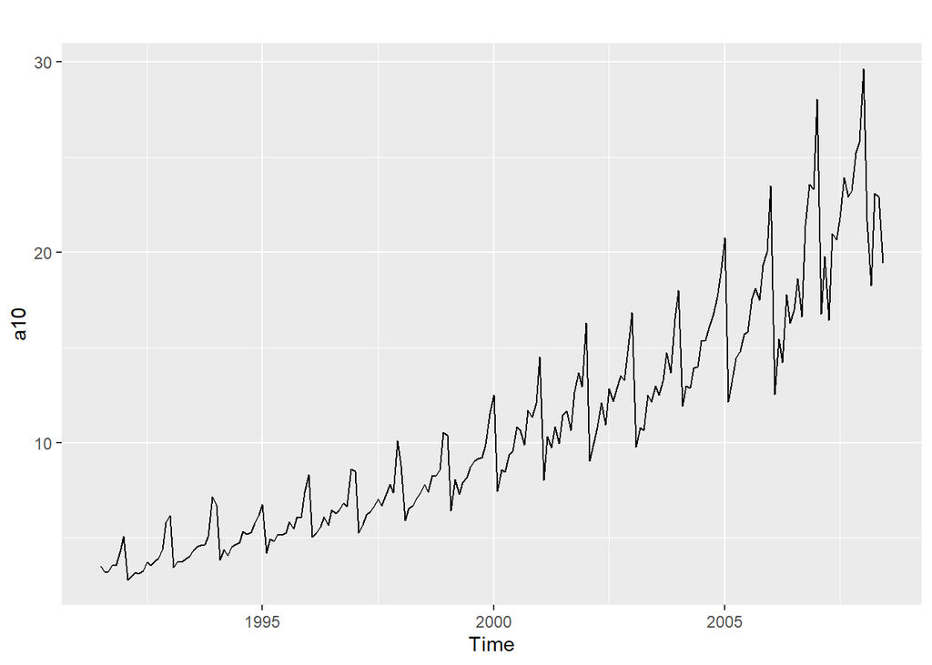

```r
# Plot the time series
autoplot(a10)
```

The data series records the monthly expenditure that the Australian government sustained within the context of the Pharmaceutical Benefit Scheme for products under the ATC code of A10 (as recorded by the Australian Health Insurance). The covered time span is from July 1991 to June 2008, documented monthly. We cannot observe the implications of the 2008 crisis, but maybe it is worth to point out that we are able to distinguish the first irregular oscillations in 2007. An economic crisis will have a nation spend less on subsidies.

The time series has increasing **trend**, the inclination of it is not incredibly steep. The **seasonality** within the series is clear (we observe 5 peaks within 5 years intervals), the amplitude of it increases over the years. A multiplicative seasonality component seems plausibale. Regarding cycles which are patterns that characterise time series but over time periods longer than a year and not as regular in frequency as seasonality.

```r
#tsibble object
a10_tsb<-a10 %>% as_tsibble()
```

### b. Apply both the decomposition methods seen in class and plot the results. Comment the results of these two procedures.

#### Classical Decomposition

Classical decomposition separates the series into 3 components: Trend, Seasonality and Residuals. The assumption made in this case is that the seasonality component does not change in amplitude over time ($S_{t+m}=S_t$), they stay constant (repeated year after year) and average to 0.

There are 2 variations of the classical decomposition: the **additive** and the **multiplicative** decomposition. Moreover, the cycle element is incorporated into the trend.

The decomposition in the classical domain assumes that the remainder is random and 0 on average, if this is not the case after we fitting the model then we should reconsider our choice, because the residuals have not been reduced to random noise. Another assumption is that trend is not moving fast, which for what we know after a simple graphical analysis seems to be our case.

To conclude, it must be mentioned that trend in classical decomposition model is estimated with moving averages, the first few and last few observations (depending on what kind of moving average has been used) will miss from the fitted model.

##### The Additive Case:

$y_t=S_t+T_t+R_t$

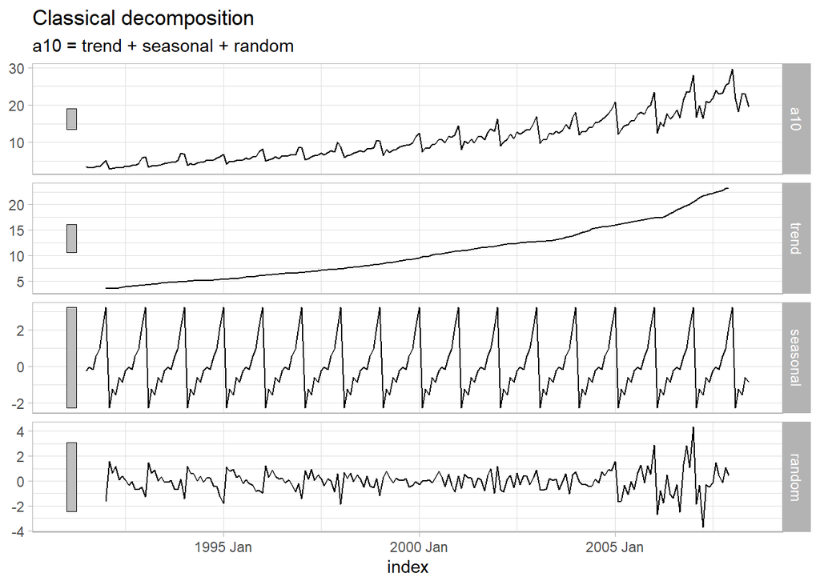

```r
# Classical Decomposition
a10_tsb %>%
  model(classical_decomposition(a10, type = "additive"))%>%
  components()%>%
  autoplot()+theme_light()
```

- **Trend:** $\hat{T}_{t+1/2}= \frac{1}{m}\sum^2_{j=-2}S_{t+j}+T_{t+j}+R_{t+j}= \frac{1}{2k}\sum^k_{j=-(k-1)}y_{t+j}$ where $m=2k$ because our period is of 12 months. It increases relatively slow, the range covered in fact is (5;25) over the span of 17 years.
- **Seasonality:** Once, we have estimated the trend we compute the de-trended series $z_t=y_t-\hat{T_t}$, the seasonality is computed by taking the average of $z_t$ for each month for every year. In our case, every monthly estimate of seasonality is the mean of circa 17 different data-points. As mentioned above, the seasonal components are corrected so that they average to 0.

In the `a10` dataset, we have seen that the seasonality component increases over the years, so an additive model in this terms does not seem like the best option.However the function extracts it as regular.

- **Remainder:** Finally, $\hat{R_t}=y_t-\hat{T_t}-\hat{S_t}$ The consequence of erroneously using the additive model is that in the residuals we can observe movements that can be directly reconnected to the time series. This means that there is autocorrelation left in the data, the remainders is not approximated to white noise.

##### The Multiplicative Case:

$y_t=S_t\times T_t\times R_t$

The multiplicative decomposition is of course equivalent to an additive model fitting the series log transformed.

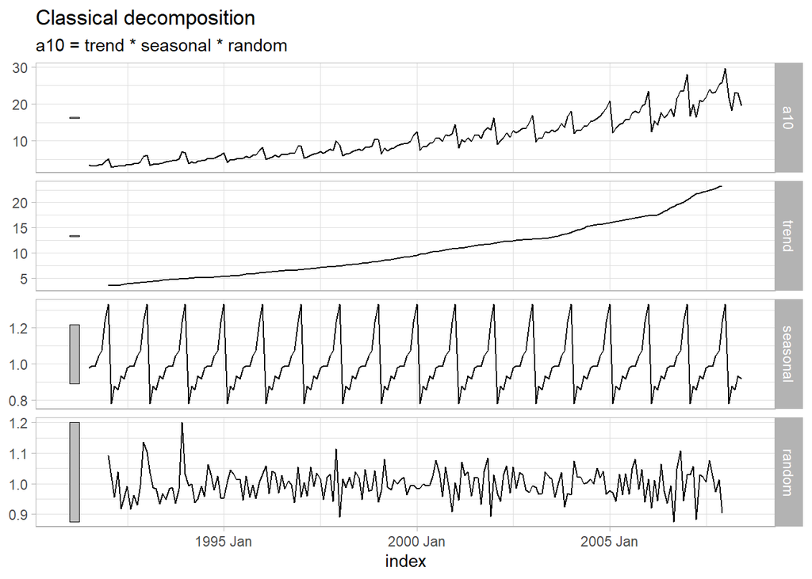

```r
# Multiplicative
a10_tsb %>%
  model(classical_decomposition(a10, type = "multiplicative"))%>%
  components()%>%
  autoplot()+theme_light()
```

All the components are computed as percentages.

- **Trend:** computed in the same way as in the additive model constructed previously.
- **Seasonality:** the procedure is described above. The correction though is different, in fact the monthly averages are corrected to include the increasing amplitude (the effects sum up to $m=12$). As in the additive case we see that the seasonal component is constant it does not vary in range over time.
- **Remainder:** is estimated as $\hat{R_t}=y_t/(\hat{T_t}\hat{S_t})$. In this case the residuals seem to be reduced to random noise.

The conclusion is that with our data the multiplicative model seems to be a better fit, even if the underlying assumptions might not be the most correct.

#### STL Decomposition

This decomposition method uses Local Regression to find a smooth function for the trend without losing observations, it also includes cycles.

The model describes the time series $y_t$ as a smooth function $g(t)$ plus an error $\epsilon_t$. $g(t)$ is estimated through linear WLS regression, therefore assumed linear within a small neighbourhood.The local estimation is repeated for each $t_0$ in the observed timespan. The regression weights are calculated from a Kernel function, which controls the smoothness of the function $\hat{g}(t_0)$.

The local regression guarantees more robustness in case of outliers. The trend estimate is more flexible.

We will transform the series using the box-cox transformation, by controlling $\lambda$ parameter we can control whether we are using a multiplicative or additive decomposition. $\lambda=0$ is the multiplicative case, $\lambda=1$ the additive one.

The transformed series is now usable for the decomposition through LOESS, the seasonality no longer increases over time.

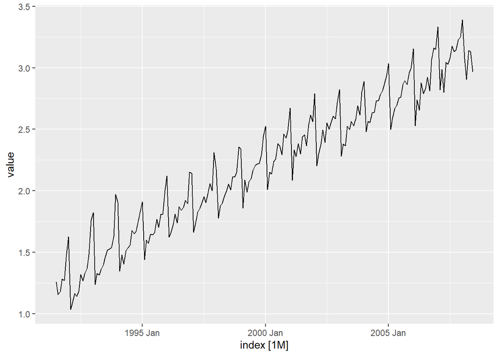

```r
# Box-Cox transformation
bcx_a10<-box_cox(a10, lambda = 0)
a10_loess2<- bcx_a10 %>% as_tsibble()
autoplot(a10_loess2)
```

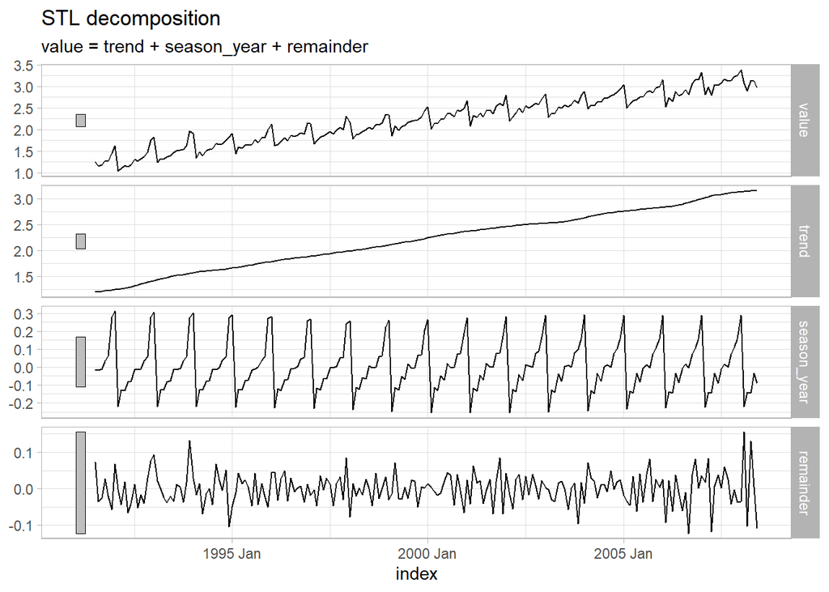

```r
# Automated version
a10_loess2 %>%
  model(stl=STL(value))%>%
  components()%>%
  autoplot()+theme_light()
```

The trend does not look over-smoothed and it has maintained the upward inclination.

Regarding the remainder the most recent portion of it still contains the higher variation that we can observe in the series around 2006 onwards. We will run some different versions of this decomposition to see if we can get different outcomes.

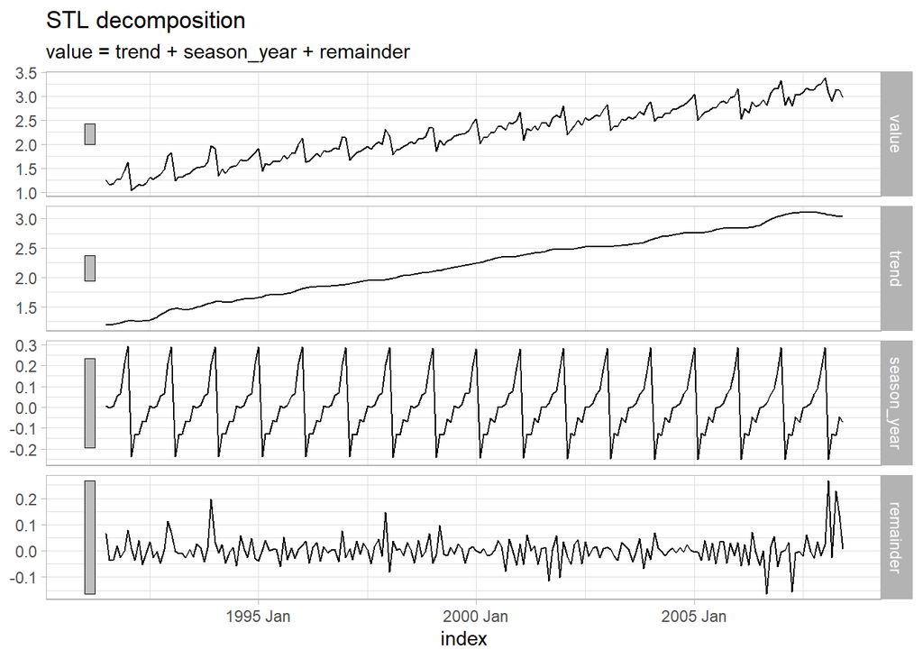

```r
a10_loess2%>%
  model(STL(value ~ trend(window=9)+season(window=17), robust=TRUE))%>%
  components()%>%
  autoplot()+theme_light()
```

We manually set the window parameters for trend and seasonality. The trend window is the number of observations used to estimate the trend-cycle element, therefore the smaller the number the “faster” the element will be allowed to change (the less smoother). 9 seems like a reasonable option, the resulting function maintains shape but without any sharp peaks.

The seasonal window in stead has been chosen considering how many years to use to estimate the seasonal component for each month. If we were to choose 17, which is the amount for years for which we have data-points. Given we are using Box-Cox transformed data the seasonal component we are extracting is constant.

The remainders look closer to white noise this time around.

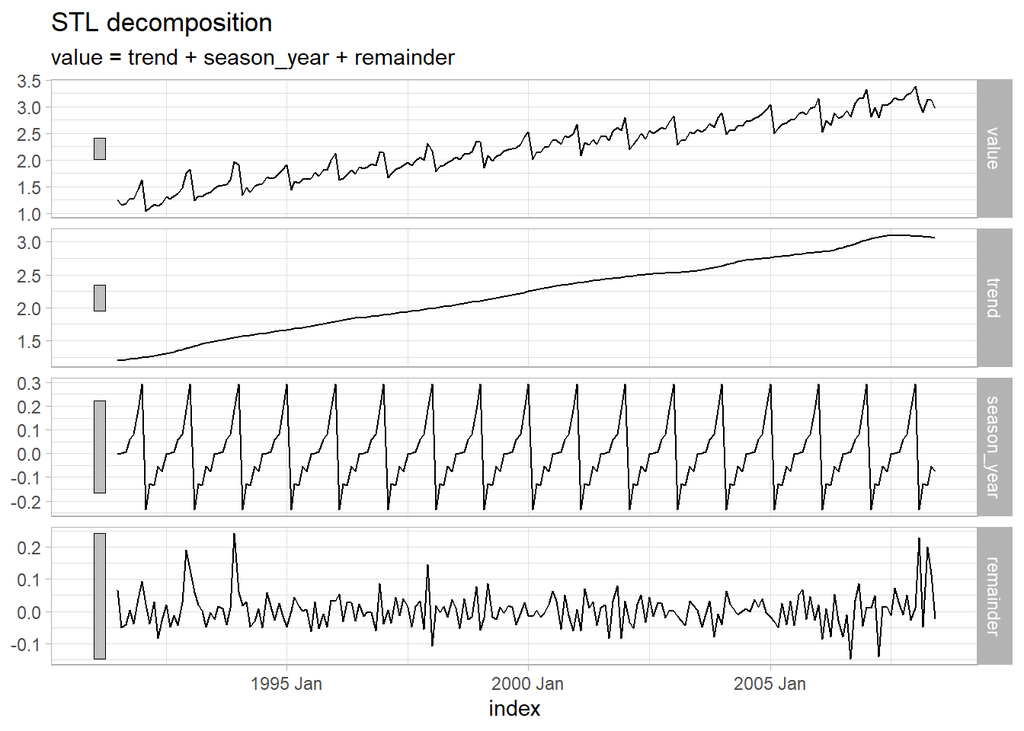

```r
# Periodic seasonality
a10_loess2%>%
  model(STL(value ~ season(window="periodic"), robust=TRUE))%>%
  components()%>%
  autoplot()+theme_light()
```

We set the seasonal component to periodic, forcing explicitly for the seasonal element to be identical every annual period.

The trend left to be approximated by R looks smoother, and finally the residuals appear more noisy than the previous trial we run.

### c. Explore different models of Exponential Smoothing (ETS), comment your results and select the model that you consider the best in fitting the series. Argument your model’s choice and further justify it by performing a residuals analysis and validating the model’s assumptions using the required statistical testing procedures.

Considering the non-transformed series, its increasing trend, the multiplicative seasonality, which grows as the level rises. We start by saying that we will not try to model seasonality as additive. Nor we will attempt to model the trend as Null. The models we will use can be categorized as Holt’s and Winters, composed by 3 equations:

- The **state/level** $l_t$ equation, representing the series level at time t;
- The **slope** $T_t$ or $b_t$ equation;
- The **seasonality** $S_t$ equation.

For reference, $m$ is the number of season in one year,$\alpha$, $\beta$, $\gamma$, $\phi$ are the smoothing parameters.

Our data is strictly positive, so we could use multiplicative models in terms of seasonality,we choose to log transform the series and model it as additive:

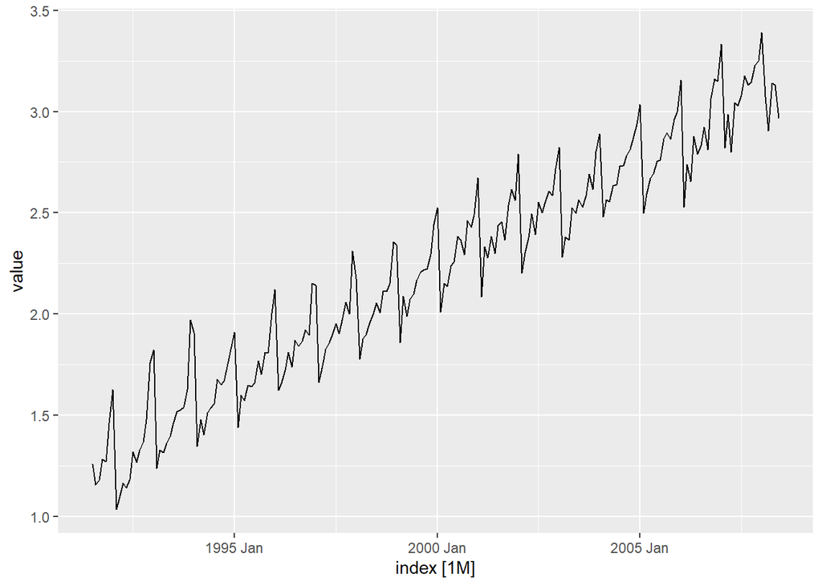

```r
# Log transformation
log_a10<-log(a10)
a10_log<- log_a10 %>% as_tsibble()
autoplot(a10_log)
```

We use the `ETS` function which uses least squares, `ets` would have used maximum likelihood.

#### A,A,A

$\begin{aligned}y_t&=l_{t-1}+ b_{t-1}+s_{t-m}+\epsilon_t\\l_t&= l_{t-1} +b_{t-1}+\alpha \epsilon_t\\b_t&= b_{t-1}+\beta\epsilon_t\\s_t&=s_{t-m}+\gamma \epsilon_t\end{aligned}$

We start with the additive error, additive trend and additive seasonality. If we were not modelling on logged data then $S_t$ would have to be interpreted as an element to be multiplied to the trend. Because we are working in Additive terms, the sum $\sum_is_i=0$

```r
m_AAA <- a10_log %>%
  model(
    AAA = ETS(value ~ error("A") + trend("A") + season("A"))
    )

report(m_AAA)
```

```
## Series: value
## Model: ETS(A,A,A)
##   Smoothing parameters:
##     alpha = 0.1377526
##     beta  = 0.0001000156
##     gamma = 0.0001024876
##
##   Initial states:
##      l[0]       b[0]        s[0]       s[-1]     s[-2]      s[-3]     s[-4]
##  1.173681 0.01001225 -0.06652255 -0.05811367 -0.142199 -0.1250138 -0.238994
##      s[-5]     s[-6]      s[-7]    s[-8]       s[-9]      s[-10]       s[-11]
##  0.2909668 0.2181497 0.07989111 0.056295 -0.01018285 0.005704941 -0.009981654
##
##   sigma^2:  0.0037
##
##       AIC      AICc       BIC
## -42.47107 -39.18075  13.93697
```

```r
# Data-frame for error values
err_AAA<-data.frame("MSE"= m_AAA[[1]][[1]]$fit$fit$MSE,"AMSE"= m_AAA[[1]][[1]]$fit$fit$AMSE, "MAE"= m_AAA[[1]][[1]]$fit$fit$MAE)
err_AAA %>% kbl()
```

| MSE | AMSE | MAE |
| --- | --- | --- |
| 0.0033695 | 0.0034056 | 0.0445515 |

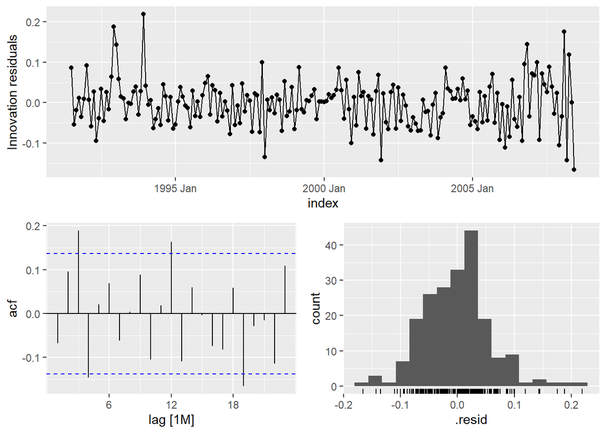

```r
# Diagnostics of Residuals
m_AAA %>% gg_tsresiduals()
```

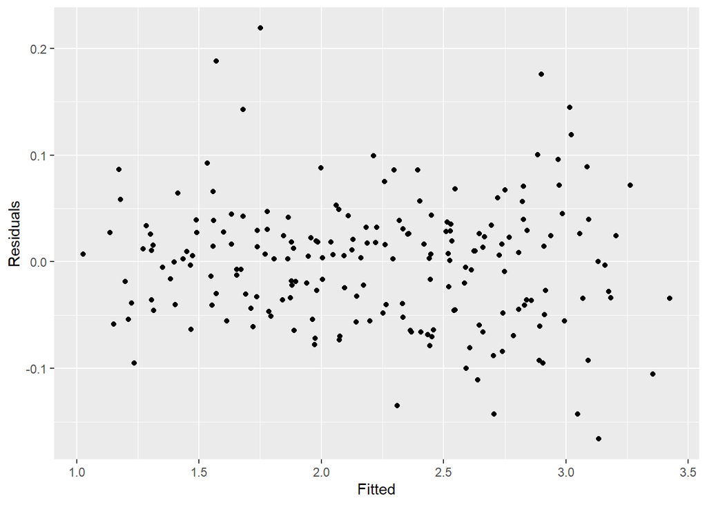

```r
# Scatter Plot of residuals
augment(m_AAA) %>%
  ggplot(aes(x = .fitted, y = .resid)) +
  geom_point() + labs(x = "Fitted", y = "Residuals")
```

```r
# Shapiro-Walk test
augment(m_AAA)$.resid %>% shapiro.test()
```

```
##
##  Shapiro-Wilk normality test
##
## data:  .
## W = 0.97866, p-value = 0.003396
```

The print out displays the smoothing parameters.

The autocorrelation plot does not look like we have managed to reduce the residuals to white noise. The histogram tails no look very symmetrical either. The scatter plot looks random enough, Yet, the residuals do not pass the Shapiro-Wilk test, the normality of residuals null hypothesis is to be rejected.

We have created a data frame of models errors, and we will do so for every model they will be recalled later on for comparison.

#### A,Ad,A

$\begin{aligned}y_t&=l_{t-1}+\phi b_{t-1}+s_{t-m}+\epsilon_t\\l_t&= l_{t-1}+\phi b_{t-1}+\alpha \epsilon_t\\b_t&=\phi b_{t-1}+\beta\epsilon_t\\s_t&=s_{t-m}+\gamma \epsilon_t\end{aligned}$

The model introduces damped trend, damping is controlled by the parameter $\phi$, $\phi = 1$ corresponds to no damping effect. The damped trend is utilized when the inclination in the trend will not be sustained in future periods, resulting in less optimistic/pessimistic forecasts.

```r
m_AAdA <- a10_log %>%
  model(
    AAdA = ETS(value ~ error("A") + trend("Ad", phi=0.9) + season("A"))
    )

report(m_AAdA)
```

```
## Series: value
## Model: ETS(A,Ad,A)
##   Smoothing parameters:
##     alpha = 0.1133123
##     beta  = 0.05291798
##     gamma = 0.000101743
##     phi   = 0.9
##
##   Initial states:
##    l[0]        b[0]        s[0]       s[-1]      s[-2]      s[-3]      s[-4]
##  1.1793 0.006651571 -0.08404266 -0.05079534 -0.1383977 -0.1313361 -0.2337883
##      s[-5]     s[-6]      s[-7]      s[-8]        s[-9]      s[-10]
##  0.2903018 0.2186973 0.08370253 0.05445592 -0.003628172 0.003300214
##        s[-11]
##  -0.008469661
##
##   sigma^2:  0.0041
##
##       AIC      AICc       BIC
## -19.74247 -16.45215  36.66557
```

```r
# Dataframe of model's errors
err_AAdA<-data.frame("MSE"= m_AAdA[[1]][[1]]$fit$fit$MSE,"AMSE"= m_AAdA[[1]][[1]]$fit$fit$AMSE, "MAE"= m_AAdA[[1]][[1]]$fit$fit$MAE)
err_AAdA %>% kbl()
```

| MSE | AMSE | MAE |
| --- | --- | --- |
| 0.0037667 | 0.0039747 | 0.0477696 |

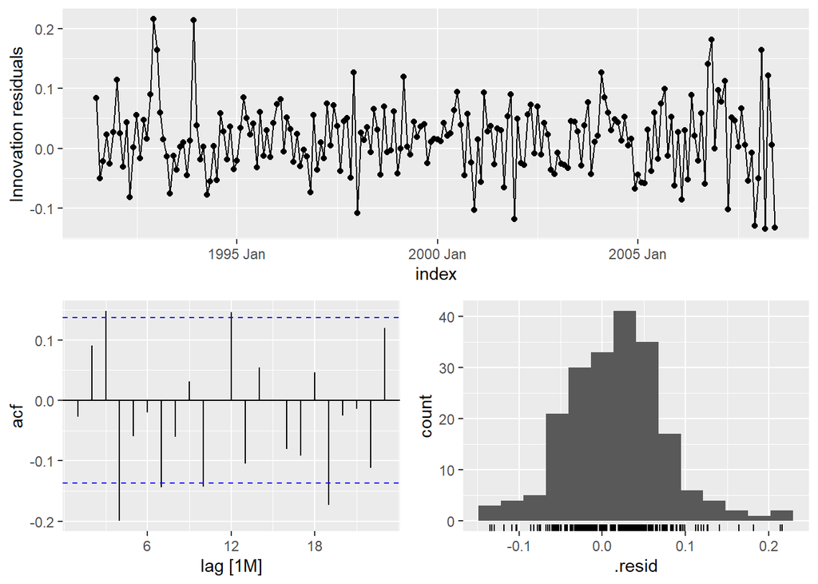

```r
m_AAdA %>% gg_tsresiduals()
```

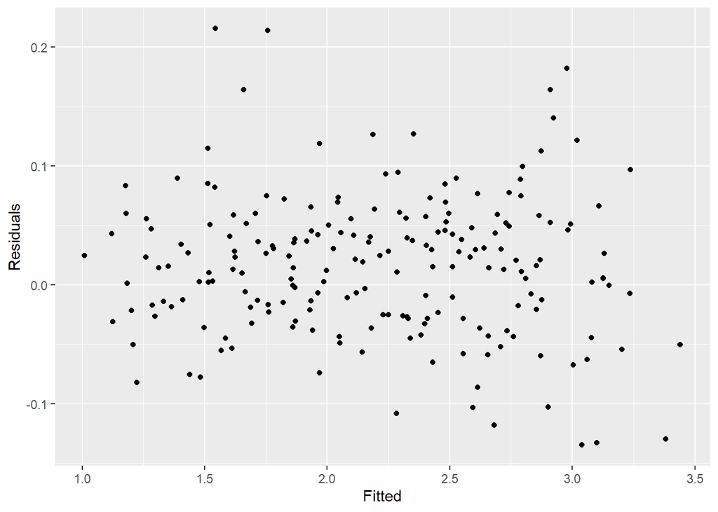

```r
# Scatter Plot of residuals
augment(m_AAdA) %>%
  ggplot(aes(x = .fitted, y = .resid)) +
  geom_point() + labs(x = "Fitted", y = "Residuals")
```

```r
# Shapiro-Walk test
augment(m_AAdA)$.resid %>% shapiro.test()
```

```
##
##  Shapiro-Wilk normality test
##
## data:  .
## W = 0.98512, p-value = 0.0303
```

#### M,A,A

$\begin{aligned}y_t&=(l_{t-1}+b_{t-1}+s_{t-m})(1+\epsilon_t)\\l_t&=l_{t-1}+b_{t-1}+\alpha(l_{t-1}+b_{t-1}+s_{t-m})\epsilon _t\\b_t&=b_{t-1}+\beta (l_{t-1}+b_{t-1}+s_{t-m})\epsilon_t\\s_t&=s_{t-m}+\gamma(l_{t-1}+b_{t-1}+s_{t-m})\epsilon_t\end{aligned}$

Here, we introduce the multiplicative error, where the variance of the error depends on the state $L_t$.The error $E\sim N(0,\sigma^2)$ can be considered because the data is strictly positive.

This implies that the larger/higher the state at time t, the bigger the uncertainty (error) of the one step-ahead forecast.

```r
m_MAA <- a10_log %>%
  model(
    MAA = ETS(value ~ error("M") + trend("A") + season("A"))
    )

report(m_MAA)
```

```
## Series: value
## Model: ETS(M,A,A)
##   Smoothing parameters:
##     alpha = 0.119001
##     beta  = 0.0001133975
##     gamma = 0.0321405
##
##   Initial states:
##      l[0]       b[0]        s[0]       s[-1]      s[-2]      s[-3]      s[-4]
##  1.180329 0.01022659 -0.08380406 -0.07135043 -0.1307482 -0.1160025 -0.2328574
##      s[-5]     s[-6]      s[-7]      s[-8]       s[-9]       s[-10]      s[-11]
##  0.2936003 0.2267845 0.07645954 0.05054561 0.002851839 -0.001031774 -0.01444741
##
##   sigma^2:  8e-04
##
##       AIC      AICc       BIC
## -39.07659 -35.78627  17.33145
```

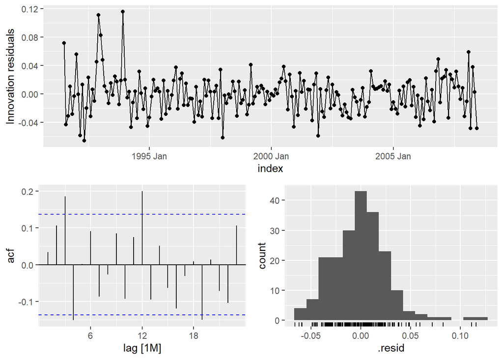

```r
m_MAA %>% gg_tsresiduals()
```

```r
# Dataframe of model's errors
err_MAA<-data.frame("MSE"= m_MAA[[1]][[1]]$fit$fit$MSE,"AMSE"= m_MAA[[1]][[1]]$fit$fit$AMSE, "MAE"= m_MAA[[1]][[1]]$fit$fit$MAE)
err_MAA %>% kbl()
```

| MSE | AMSE | MAE |
| --- | --- | --- |
| 0.0034631 | 0.003509 | 0.0206714 |

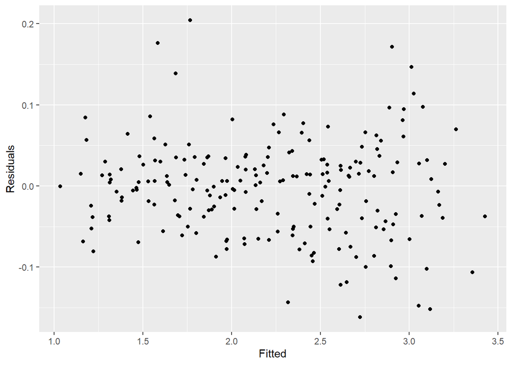

```r
# Scatter Plot of residuals
augment(m_MAA) %>%
  ggplot(aes(x = .fitted, y = .resid)) +
  geom_point() + labs(x = "Fitted", y = "Residuals")
```

```r
# Shapiro-Walk test
augment(m_MAA)$.resid %>% shapiro.test()
```

```
##
##  Shapiro-Wilk normality test
##
## data:  .
## W = 0.98435, p-value = 0.02314
```

We will compare this model with the ETS(A,A,A) in terms of model selection criteria to see if what error seems to be the best, given all is equal.

#### M,Ad,A

$\begin{aligned}y_t&=(l_{t-1}+\phi b_{t-1}s_{t-m}(1+\epsilon_t))\\l_t&=(l_{t-1}+\phi b_{t-1})(1+\alpha\epsilon _t)\\b_t&=\phi b_{t-1}+\beta (l_{t-1}+\phi b_{t-1})\epsilon_t\\s_t&=s_{t-m}(1+\gamma\epsilon_t)\end{aligned}$

```r
m_MAdA <- a10_log %>%
  model(
    MAdA = ETS(value ~ error("M") + trend("Ad", phi=0.9) + season("A"))
    )

report(m_MAdA)
```

```
## Series: value
## Model: ETS(M,Ad,A)
##   Smoothing parameters:
##     alpha = 0.1684941
##     beta  = 0.05902181
##     gamma = 0.0001001782
##     phi   = 0.9
##
##   Initial states:
##      l[0]        b[0]        s[0]       s[-1]      s[-2]      s[-3]      s[-4]
##  1.187899 0.009403932 -0.08515956 -0.07707403 -0.1287708 -0.1289912 -0.2262276
##      s[-5]     s[-6]      s[-7]      s[-8]       s[-9]      s[-10]      s[-11]
##  0.2938714 0.2448073 0.07366303 0.04823716 -0.00554916 -0.01417418 0.005367754
##
##   sigma^2:  9e-04
##
##       AIC      AICc       BIC
## -18.58834 -15.29802  37.81970
```

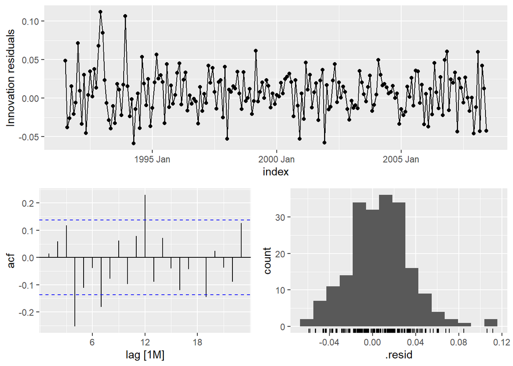

```r
m_MAdA %>% gg_tsresiduals()
```

```r
# Dataframe of model's errors
err_MAdA<-data.frame("MSE"= m_MAdA[[1]][[1]]$fit$fit$MSE,"AMSE"= m_MAdA[[1]][[1]]$fit$fit$AMSE, "MAE"= m_MAdA[[1]][[1]]$fit$fit$MAE)
err_MAdA %>% kbl()
```

| MSE | AMSE | MAE |
| --- | --- | --- |
| 0.0039027 | 0.0041421 | 0.0226692 |

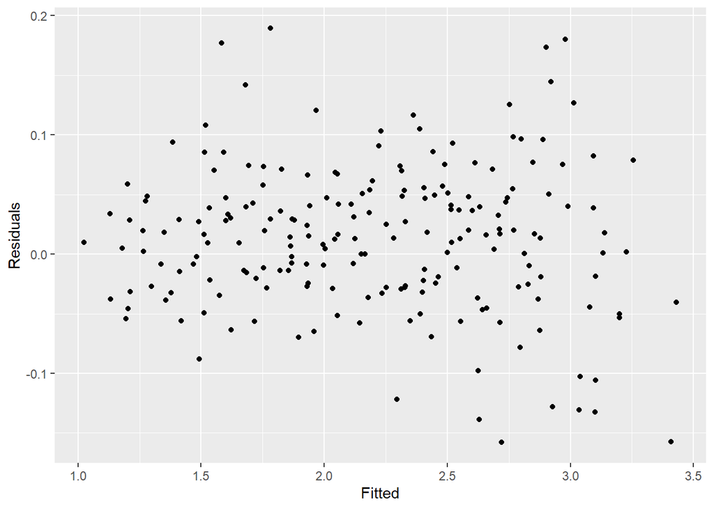

```r
# Scatter Plot of residuals
augment(m_MAdA) %>%
  ggplot(aes(x = .fitted, y = .resid)) +
  geom_point() + labs(x = "Fitted", y = "Residuals")
```

```r
# Shapiro-Walk test
augment(m_MAdA)$.resid %>% shapiro.test()
```

```
##
##  Shapiro-Wilk normality test
##
## data:  .
## W = 0.98866, p-value = 0.1055
```

#### Conclusions:

We look at the model selection criteria, so to select the “best” model. The AIC, AICc, BIC metrics point to the ETS(A,A,A) model.

We recall the errors data-frames we built to compare them and gain a clearer picture.

```r
err_AAA
```

```
##           MSE        AMSE        MAE
## 1 0.003369543 0.003405575 0.04455146
```

```r
err_AAdA
```

```
##           MSE        AMSE        MAE
## 1 0.003766672 0.003974679 0.04776964
```

```r
err_MAA
```

```
##           MSE        AMSE        MAE
## 1 0.003463143 0.003508992 0.02067138
```

```r
err_MAdA
```

```
##           MSE        AMSE        MAE
## 1 0.003902731 0.004142074 0.02266917
```

```r
min(err_AAA$MAE, err_AAdA$MAE, err_MAA$MAE, err_MAdA$MAE)
```

```
## [1] 0.02067138
```

The model function `ETS` estimates the errors Mean Squared Error, Adjusted Mean Squared Error and Mean Absolute Error.

The model displaying the minimum MSE, AMSE is the ETS(A,A,A), the one with the smallest MAE is ETS(M,A,A). These models have the same parameters but different error, this means that they will produce the same point forecast but with different prediction intervals.

For this reason we will plot the confidence intervals and see which model has more precise forecasts.

#### Considerations:

As one can see we have only worked with the log-tranformed series, we will try to fit a multiplicative seasonality model, avoiding ETS(A,A,M) or ETS(A,Ad,M) which are not very stable options and are usually not considered.

We fit and explore the residuals for the ETS(M,A,M):

```r
m_MAM <- a10_tsb %>%
  model(
    MAM = ETS(value ~ error("M") + trend("A") + season("M"))
    )

#Main statistics
report(m_MAM)
```

```
## Series: value
## Model: ETS(M,A,M)
##   Smoothing parameters:
##     alpha = 0.2045297
##     beta  = 0.008735247
##     gamma = 0.000100136
##
##   Initial states:
##      l[0]       b[0]      s[0]     s[-1]     s[-2]     s[-3]     s[-4]    s[-5]
##  3.264031 0.05152271 0.9106847 0.9340223 0.8634518 0.8720877 0.7898464 1.327494
##     s[-6]    s[-7]    s[-8]     s[-9]    s[-10]    s[-11]
##  1.234262 1.069468 1.043805 0.9874291 0.9861423 0.9813052
##
##   sigma^2:  0.0038
##
##      AIC     AICc      BIC
## 867.9383 871.2286 924.3463
```

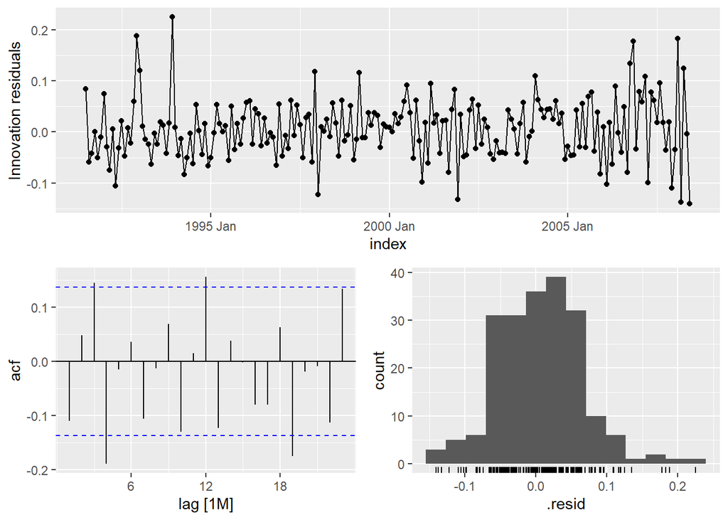

```r
#Diagnostics
m_MAM %>% gg_tsresiduals()
```

```r
# Dataframe of model's errors
err_MAM<-data.frame("MSE"= m_MAM[[1]][[1]]$fit$fit$MSE,"AMSE"= m_MAM[[1]][[1]]$fit$fit$AMSE, "MAE"= m_MAM[[1]][[1]]$fit$fit$MAE)
err_MAM %>% kbl()
```

| MSE | AMSE | MAE |
| --- | --- | --- |
| 0.7000994 | 0.7007736 | 0.0460136 |

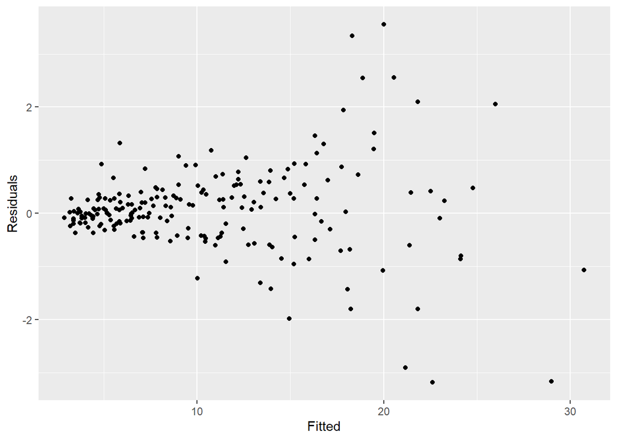

```r
# Scatter Plot of residuals
augment(m_MAM) %>%
  ggplot(aes(x = .fitted, y = .resid)) +
  geom_point() + labs(x = "Fitted", y = "Residuals")
```

```r
# Shapiro-Walk test
augment(m_MAM)$.resid %>% shapiro.test()
```

```
##
##  Shapiro-Wilk normality test
##
## data:  .
## W = 0.89413, p-value = 7.992e-11
```

The resulting model really struggles to extract autocorrelation from the residuals, in fact the scatter plot does not look random, the ACF plot signals a lot of autocorrelated lags. Moreover, it does not pass the normality test.

### d. Compute a h = 10 forecast and prediction intervals for different levels: 80%, 90%, 95% and 99%.

We have stated before that the ETS(A,A,A) and the ETS(M,A,A) produce the same point forecast, we check graphically if that is the case.

```r
# Comparison Point forecast
fit_comp <- a10_log %>%
  model(
    AAA = ETS(value ~ error("A") + trend("A") + season("A")),
    MAA= ETS(value~ error("M") + trend("A") + season("A"))
    )

fc_comp <- fit_comp %>% fabletools::forecast(h=10)
fc_comp
```

```
## # A fable: 20 x 4 [1M]
## # Key:     .model [2]
##    .model    index          value .mean
##    <chr>     <mth>         <dist> <dbl>
##  1 AAA    2008 Jul N(3.2, 0.0037)  3.18
##  2 AAA    2008 Aug N(3.2, 0.0037)  3.20
##  3 AAA    2008 Sep N(3.2, 0.0038)  3.20
##  4 AAA    2008 Oct N(3.3, 0.0039)  3.27
##  5 AAA    2008 Nov N(3.3, 0.0039)  3.31
##  6 AAA    2008 Dec  N(3.5, 0.004)  3.45
##  7 AAA    2009 Jan N(3.5, 0.0041)  3.54
##  8 AAA    2009 Feb   N(3, 0.0041)  3.02
##  9 AAA    2009 Mar N(3.1, 0.0042)  3.14
## 10 AAA    2009 Apr N(3.1, 0.0043)  3.13
## 11 MAA    2008 Jul N(3.2, 0.0082)  3.18
## 12 MAA    2008 Aug N(3.2, 0.0085)  3.20
## 13 MAA    2008 Sep N(3.2, 0.0086)  3.21
## 14 MAA    2008 Oct N(3.3, 0.0091)  3.27
## 15 MAA    2008 Nov N(3.3, 0.0094)  3.31
## 16 MAA    2008 Dec   N(3.5, 0.01)  3.46
## 17 MAA    2009 Jan  N(3.5, 0.011)  3.54
## 18 MAA    2009 Feb   N(3, 0.0084)  3.03
## 19 MAA    2009 Mar N(3.1, 0.0091)  3.15
## 20 MAA    2009 Apr N(3.1, 0.0092)  3.15
```

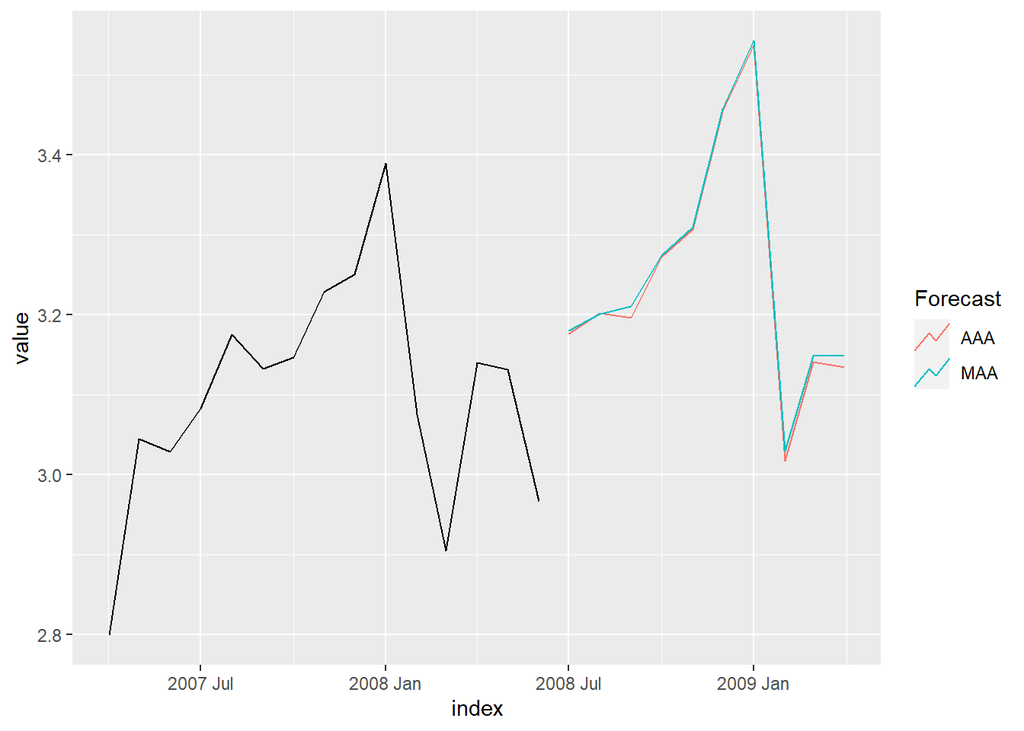

```r
fc_comp %>% autoplot(a10_log[190:204,], level = NULL) +
  guides(colour = guide_legend(title = "Forecast"))
```

The point forecasts are very similar. We compute the prediction intervals which are the regions within which we expect the forecast (the true one, not the estimated one) to lie.

By doing this we are assuming normality of the residuals.

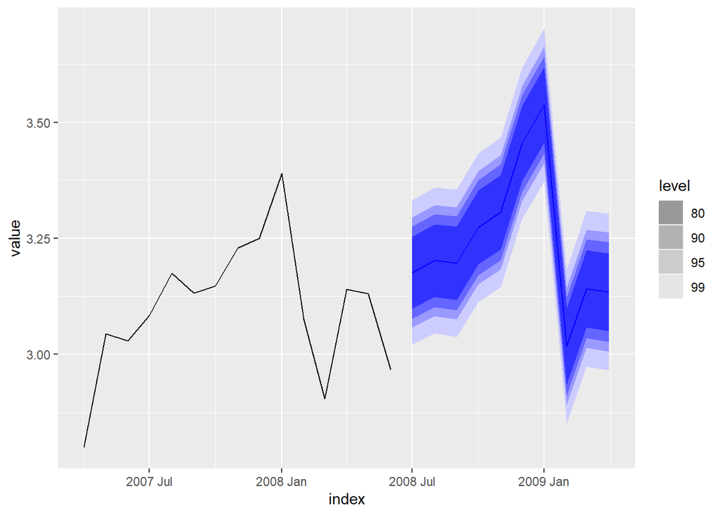

```r
# Confidence intervals for ETS(A,A,A)
AAA_fc<-m_AAA %>% fabletools::forecast(h=10,level=c(80,90,95,99))
ci_aaa<-AAA_fc %>% hilo(level=c(80,90,95,99))
AAA_fc %>% autoplot(a10_log[190:204,], level=c(80,90,95,99))
```

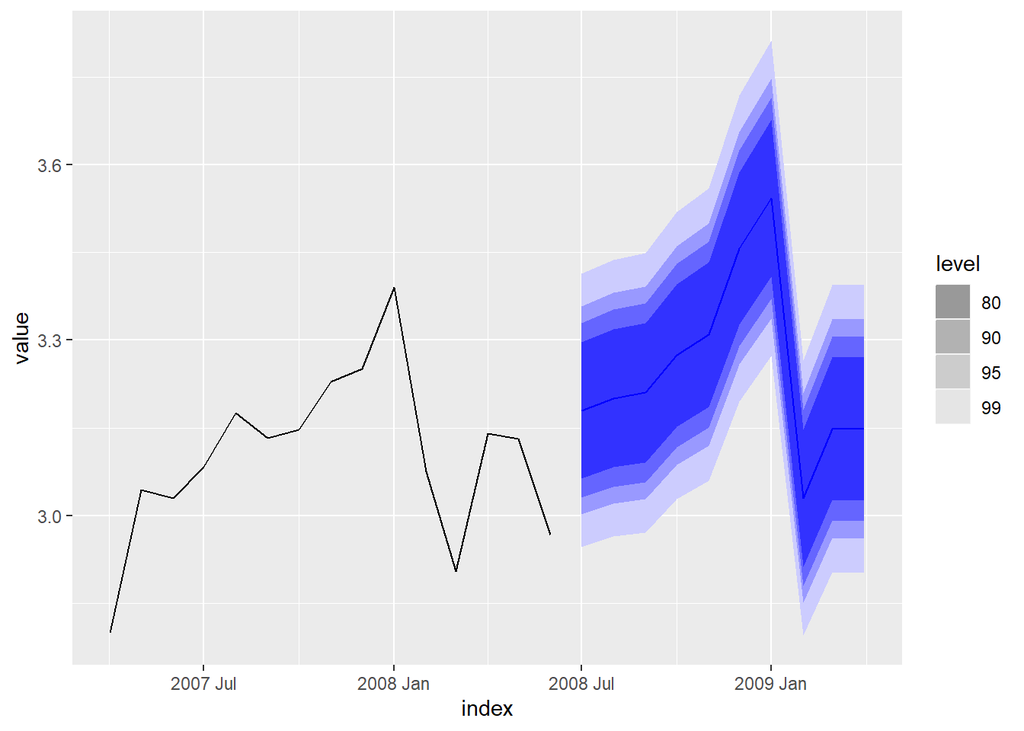

```r
# Confidence Intervals for ETS(M,A,A)
MAA_fc<-m_MAA %>% fabletools::forecast(h=10,level=c(80,90,95,99))
ci_maa<-MAA_fc %>% hilo(level=c(80,90,95,99))
MAA_fc %>% autoplot(a10_log[190:204,], level=c(80,90,95,99))
```

Graphically, it seems like the intervals are larger for the multiplicative error, which we have already stated grows with the level of series. As the level of the time series increases/decreases the error will vary in proportion.

```r
#Comparison of intervals
ci_aaa$`80%`$upper-ci_aaa$`80%`$lower> ci_maa$`80%`$upper-ci_maa$`80%`$lower
```

```
##  [1] FALSE FALSE FALSE FALSE FALSE FALSE FALSE FALSE FALSE FALSE
```

```r
ci_aaa$`90%`$upper-ci_aaa$`90%`$lower> ci_maa$`90%`$upper-ci_maa$`90%`$lower
```

```
##  [1] FALSE FALSE FALSE FALSE FALSE FALSE FALSE FALSE FALSE FALSE
```

```r
ci_aaa$`95%`$upper-ci_aaa$`95%`$lower> ci_maa$`95%`$upper-ci_maa$`95%`$lower
```

```
##  [1] FALSE FALSE FALSE FALSE FALSE FALSE FALSE FALSE FALSE FALSE
```

```r
ci_aaa$`99%`$upper-ci_aaa$`99%`$lower> ci_maa$`99%`$upper-ci_maa$`99%`$lower
```

```
##  [1] FALSE FALSE FALSE FALSE FALSE FALSE FALSE FALSE FALSE FALSE
```

The confidence intervals are different, and the one for ETS(A,A,A) is smaller, which was to be expected. Therefore, we choose ETS(A,A,A) as optimal model.

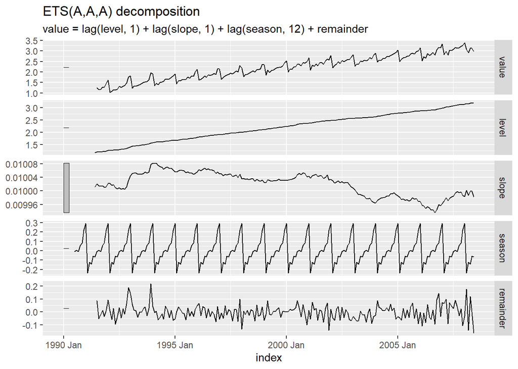

```r
# Components of the optimal model
components(m_AAA)%>% autoplot()
```

The ranges in the components of course are of the logged time-series. We have not re-iterated this concept a lot throught out the exercise but it is important to remember.

- The level is increasing;
- The slope is not a constant inceasing motion;
- The seasonality because of the logged time series is quite regular;
- The residuals look random enough but we already know how they leave quite a lot to be desired. The seasonality seems regular, but of course it is because we are working with logged data.

### e. Compute a h = 10 forecast and prediction intervals for the same levels of the previous point, this time by using bootstrapping: a) assuming normality of residuals and b) sampling based on your fitted model’s residuals

We do this for the model ETS(A,A,A).

$\begin{aligned}y_t&=l_{t-1}+ b_{t-1}+s_{t-m}+\epsilon_t\\l_t&= l_{t-1} +b_{t-1}+\alpha \epsilon_t\\b_t&= b_{t-1}+\beta\epsilon_t\\s_t&=s_{t-m}+\gamma \epsilon_t\end{aligned}$

The **level** equation is modelled as the sum of the last level component, the previous slope component. With the smoothing parameter alpha

The seasonality element in the $y_t$ equation is the seasonality component for the last seasonal period, this means that for every step ahead we would need to update the seasonal component. That would be very complicated, we check it is acceptable enough to use the same seasonal components (the ones belonging to the last year).

```r
# we check the variance of the seasonal components
A <- components(m_AAA)$season
dim(A) <- c(12, 18) # 12 seasons, 18 years
A <- t(A)
apply(A,2,var) # compute the variance
```

```
##  [1] 3.956218e-11 6.132861e-11 2.649463e-11 2.056719e-11 9.055177e-11
##  [6] 4.359986e-10 1.301314e-10 5.266122e-11 2.890034e-11 2.773922e-11
## [11] 4.035110e-11 6.732636e-11
```

The variance of the seasonal components for each month across the 18 years if data recorded appear to be very small. To use the seasonal components from the last “observed” period is acceptable.

```r
# We initialise the needed variables:

# Smoothing paramteres
alpha<- m_AAA[[1]][[1]]$fit$par$estimate[1]
beta<-m_AAA[[1]][[1]]$fit$par$estimate[2]

# Sigma
sigma<- sqrt(m_AAA[[1]][[1]]$fit$fit$sigma2)

# Initial States
l <- components(m_AAA)$level[216]
b <- components(m_AAA)$slope[216]

# Vector of seasonal components
seasons <- components(m_AAA)$season[205:216]
```

#### Assuming Normality

We assume normality of the residuals which is not the case for this data-set, we have seen how the residuals of the model do not pass the normality test.

Normal simulations depend on the underlying model, we know that our “optimal” model is not does not fit the data well. Assuming normality of the residuals where there is not is not the best of options. Moreover, they do not incorporate model uncertainty, they do no account for possible error in the model itself.

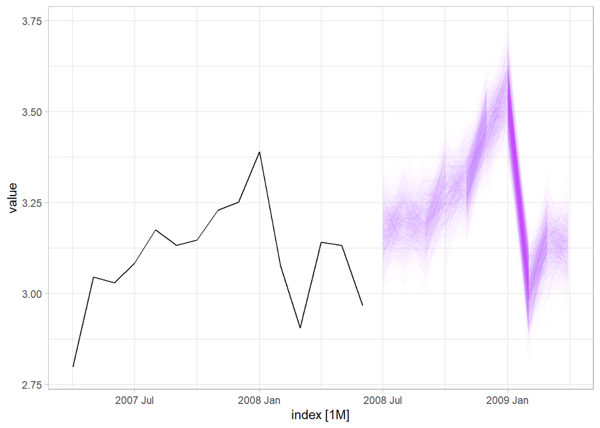

```r
# Set the random seed to have always the same generation
set.seed(1)  # controlled random generation
h_step <- 10 #numbers of steps ahead
R <- 1000 # num of replicates
range <-seq(205, 204 +h_step,1)
l_mat <- matrix(nrow = h_step, ncol = R)
b_mat <- matrix(nrow = h_step, ncol = R)
y <- matrix(nrow = h_step, ncol = R)
method= "rand"

  if(method == "rand"){
    # Use random sample to plot simulation
    eps <- rnorm(n=R, mean=0, sd=sigma)
    samp_type <- "Random sampling"
  } else if (method == "Bootstrapping"){
    # Use bootstrap re-sampling to get new residuals. Removing first value using -1
    eps <- sample(x = components(m_AAA)$remainder[-1], size = R, replace = T)
    samp_type <- "Boostrap sampling"
  }

# Initialisation of the smoothing and forecast equations
y[1, ] <- l + b + seasons[1] + eps
l_mat[1, ] <- l + b + alpha*eps
b_mat[1, ] <- b + beta*eps


# Generating the h step ahead simulations, for each method of choice
  for(h in 2:h_step) {
      forecast_row = 216 + h
      season_coeff = seasons[forecast_row %% 12]

      if(method == "rand"){
        # Assuming normality
        eps <- rnorm(n=R, mean=0, sd=sigma)
      } else if (method== "Bootstrapping") {
        # Bootstrapping, the first remainder is an NA
        eps <- sample(x = components(m_AAA)$remainder[-1], size = R, replace = T)
      }

    # Filling in the matrix of the simulation
    y[h,] <- l_mat[h-1,] + b_mat[h-1,] + season_coeff + eps
    l_mat[h,] <- l_mat[h-1,] + b_mat[h-1,] + alpha*eps
    b_mat[h,] <- b_mat[h-1,] + beta*eps
  }
# To plot the simulation, which is not indexed
dates <- seq(ymd("2008-07-01"), ymd("2009-04-01"), by = 'month')

# Plotting the series and R simulations
autoplot(a10_log[190:204,])+
  geom_line(data=melt(y), aes(x= rep(dates, R)  , y=value, color=as.factor(Var2)), alpha=0.01)+
  guides(color="none") +
  scale_color_discrete(type = rep("purple", R)) + theme_light()
```

```r
conf_levels<- c(0.80,0.90,0.95,0.99)


# Confidence intervals
for (i in 1:nrow(y)) {
  # calculate mean of row i
  mean_i <- mean(y[i,])
  print(paste("The mean for step", i, "is", mean_i))

  # loop through each confidence level
  for (j in 1:length(conf_levels)) {
    # calculate confidence interval
    ci_i <- t.test(y[i,], conf.level = conf_levels[j])$conf.int
    print(paste("The", conf_levels[j]*100, "% confidence interval is:", ci_i[1], ci_i[2]))
  }
}
```

```
## [1] "The mean for step 1 is 3.17600153298442"
## [1] "The 80 % confidence interval is: 3.17346377588476 3.17853929008408"
## [1] "The 90 % confidence interval is: 3.17274348961949 3.17925957634935"
## [1] "The 95 % confidence interval is: 3.17211823008 3.17988483588884"
## [1] "The 99 % confidence interval is: 3.17089443435072 3.18110863161812"
## [1] "The mean for step 2 is 3.20127254222292"
## [1] "The 80 % confidence interval is: 3.19869626215675 3.20384882228909"
## [1] "The 90 % confidence interval is: 3.19796504199883 3.204580042447"
## [1] "The 95 % confidence interval is: 3.19733029106543 3.20521479338041"
## [1] "The 99 % confidence interval is: 3.1960879182068 3.20645716623904"
## [1] "The mean for step 3 is 3.1971617735193"
## [1] "The 80 % confidence interval is: 3.19456022353309 3.19976332350551"
## [1] "The 90 % confidence interval is: 3.19382183106687 3.20050171597173"
## [1] "The 95 % confidence interval is: 3.19318085406141 3.20114269297719"
## [1] "The 99 % confidence interval is: 3.19192629515857 3.20239725188004"
```

[output cut: 35 more lines]

#### Bootstrapping

In this case we do not assume normality of the residuals, which is actually the case. For us this would the right choice for us to perform a simulation. We are randomly re-sampling the estimated error with replacement.

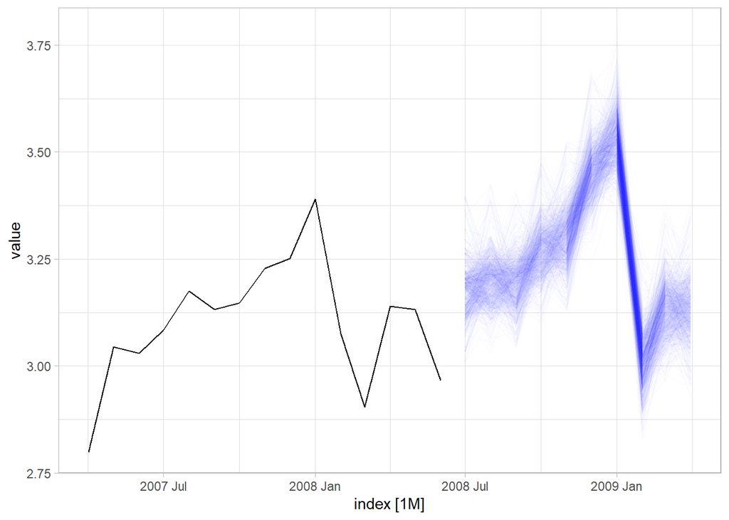

```r
# Set the random seed to have always the same generation
set.seed(2) # controlled random generation
h_step <- 10 #numbers of steps ahead
R <- 1000 # num of replicates
range <-seq(205, 204 +h_step,1)
l_mat2 <- matrix(nrow = h_step, ncol = R)
b_mat2 <- matrix(nrow = h_step, ncol = R)
y2 <- matrix(nrow = h_step, ncol = R)
method = "Bootstrapping"

  if(method == "rand"){
    # Assuming normality
    eps <- rnorm(n=R, mean=0, sd=sigma)
    samp_type <- "Random sampling"
  } else if (method == "Bootstrapping"){
    # Bootstrapping, the first of the remainder is an NA
    eps <- sample(x = components(m_AAA)$remainder[-1], size = R, replace = T)
    samp_type <- "Boostrap sampling"
  }

# Initialisation of the smoothing and forecast equations
y2[1, ] <- l + b + seasons[1] + eps
l_mat2[1, ] <- l + b + alpha*eps
b_mat2[1, ] <- b + beta*eps


# Generating the h step ahead simulations, for each method of choice
  for(h in 2:h_step) {
      forecast_row = 216 + h
      season_coeff = seasons[forecast_row %% 12]

      if(method == "rand"){
        # Assuming normality
        eps <- rnorm(n=R, mean=0, sd=sigma)
      } else if (method== "Bootstrapping") {
        # Boostrapping, the first remainder is an NA
        eps <- sample(x = components(m_AAA)$remainder[-1], size = R, replace = T)
      }

    #Filling in the matrix for the simulation
    y2[h,] <- l_mat[h-1,] + b_mat[h-1,] + season_coeff + eps
    l_mat2[h,] <- l_mat[h-1,] + b_mat[h-1,] + alpha*eps
    b_mat2[h,] <- b_mat[h-1,] + beta*eps
  }

# To plot the simulation, which is not indexed
dates <- seq(ymd("2008-07-01"), ymd("2009-04-01"), by = 'month')

# Plotting the series and R simulations
autoplot(a10_log[190:204,])+
  geom_line(data=melt(y2), aes(x= rep(dates, R)  , y=value, color=as.factor(Var2)), alpha=0.01)+
  guides(color="none") +
  scale_color_discrete(type = rep("blue", R)) + theme_light()
```

```r
# Confidence intervals
for (i in 1:nrow(y2)) {
  # calculate mean of row i
  mean_i <- mean(y2[i,], na.rm = TRUE)
  print(paste("The mean for step", i, "is", mean_i))

  # loop through each confidence level
  for (j in 1:length(conf_levels)) {
    # calculate confidence interval
    ci_i <- t.test(y2[i,], conf.level = conf_levels[j])$conf.int
    print(paste("The", conf_levels[j]*100, "% confidence interval is:", ci_i[1], ci_i[2]))
  }
}
```

```
## [1] "The mean for step 1 is 3.17600370041525"
## [1] "The 80 % confidence interval is: 3.17356880469337 3.17843859613713"
## [1] "The 90 % confidence interval is: 3.17287767223034 3.17912972860015"
## [1] "The 95 % confidence interval is: 3.17227769567228 3.17972970515821"
## [1] "The 99 % confidence interval is: 3.17110330178857 3.18090409904192"
## [1] "The mean for step 2 is 3.20178561648347"
## [1] "The 80 % confidence interval is: 3.19943022522229 3.20414100774465"
## [1] "The 90 % confidence interval is: 3.19876165432258 3.20480957864436"
## [1] "The 95 % confidence interval is: 3.1981812603971 3.20538997256983"
## [1] "The 99 % confidence interval is: 3.19704518665664 3.20652604631029"
## [1] "The mean for step 3 is 3.19401504331357"
## [1] "The 80 % confidence interval is: 3.19167790630903 3.19635218031811"
## [1] "The 90 % confidence interval is: 3.19101452478442 3.19701556184272"
## [1] "The 95 % confidence interval is: 3.1904386405711 3.19759144605604"
## [1] "The 99 % confidence interval is: 3.18931141038749 3.19871867623965"
```

[output cut: 35 more lines]